# Sentiment Analysis

Dai Yichao (IVAN)

4/15/2021

## AAPL

### Read Text file and Text Cleanning

The following table shows the tweet number per hour with a barplot.

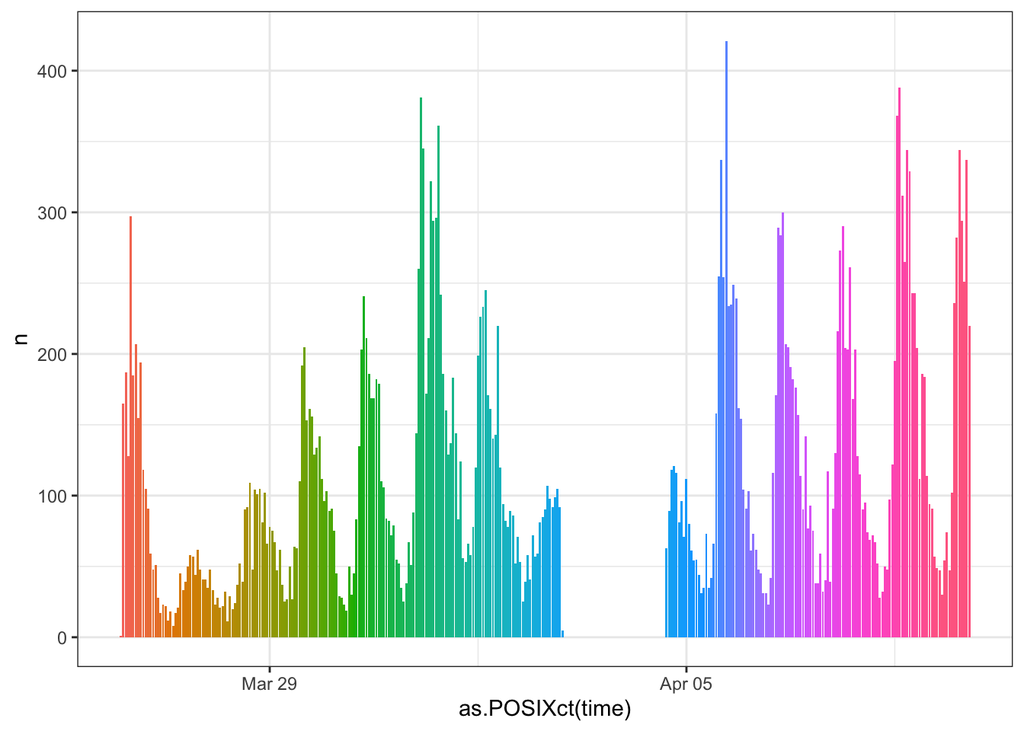

paste all the text together group by hour, the following table shows an example of the text dataframe.

```
## # A tibble: 6 x 3
## # Groups:   date [1]
##   date       time            text
##   <date>     <chr>           <chr>
## 1 2021-03-26 2021-03-26 12:… " Notable open interest changes for March th AAPL …
## 2 2021-03-26 2021-03-26 13:… " Get ahead of the trend here at Xtraders Congrats…
## 3 2021-03-26 2021-03-26 14:… " The Secrets They Don t Want You To Know   You ar…
## 4 2021-03-26 2021-03-26 15:… " Collect Per Month In Passive Income With A Freed…
## 5 2021-03-26 2021-03-26 16:… " BTC Bitcoin Right from Morgan Stanley Private We…
## 6 2021-03-26 2021-03-26 17:… " Most Active Equity Options For Midday Friday Mar…
```

```
## [1] "there are total 302 observation"
```

### Sentiment Data frame with bing, afinn, and nrc

We start with the bing data frame

```
## # A tibble: 6 x 3
## # Groups:   date [1]
##   date       time                sentiment
##   <date>     <chr>                   <dbl>
## 1 2021-03-26 2021-03-26 13:00:00       -23
## 2 2021-03-26 2021-03-26 14:00:00        -4
## 3 2021-03-26 2021-03-26 15:00:00        17
## 4 2021-03-26 2021-03-26 16:00:00        -2
## 5 2021-03-26 2021-03-26 17:00:00       -28
## 6 2021-03-26 2021-03-26 18:00:00         1
```

then, we normalize the sentiment, normalized data has mean = 0 // aother way is rescale to c(-3,3)

```
## # A tibble: 6 x 3
## # Groups:   date [1]
##   date       time                sentiment
##   <date>     <chr>                   <dbl>
## 1 2021-03-26 2021-03-26 13:00:00    -1.75
## 2 2021-03-26 2021-03-26 14:00:00    -0.869
## 3 2021-03-26 2021-03-26 15:00:00     0.109
## 4 2021-03-26 2021-03-26 16:00:00    -0.776
## 5 2021-03-26 2021-03-26 17:00:00    -1.99
## 6 2021-03-26 2021-03-26 18:00:00    -0.636
```

and then, we plot the normalized sentiment against the time.

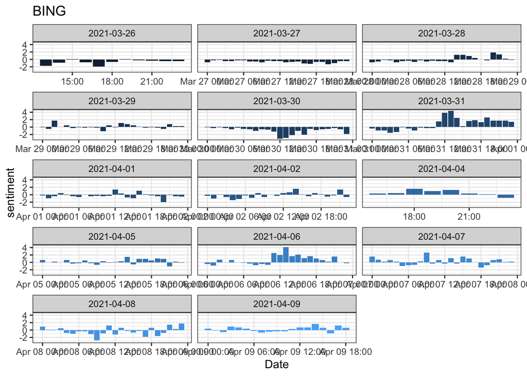

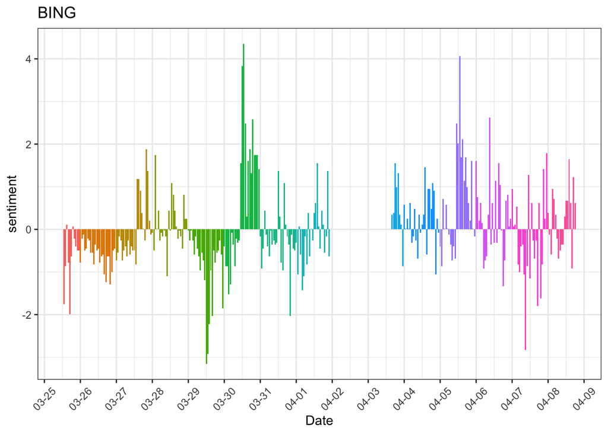

And then, we deal with the afinn sentiment dataframe

```
## # A tibble: 6 x 3
## # Groups:   date [1]
##   date       time                sentiment
##   <date>     <chr>                   <dbl>
## 1 2021-03-26 2021-03-26 13:00:00   -0.998
## 2 2021-03-26 2021-03-26 14:00:00    0.0244
## 3 2021-03-26 2021-03-26 15:00:00    0.566
## 4 2021-03-26 2021-03-26 16:00:00   -0.236
## 5 2021-03-26 2021-03-26 17:00:00   -1.08
## 6 2021-03-26 2021-03-26 18:00:00   -0.0157
```

and then, we plot the normalized sentiment against the time. // Aother method is rescale to c(-3,3)

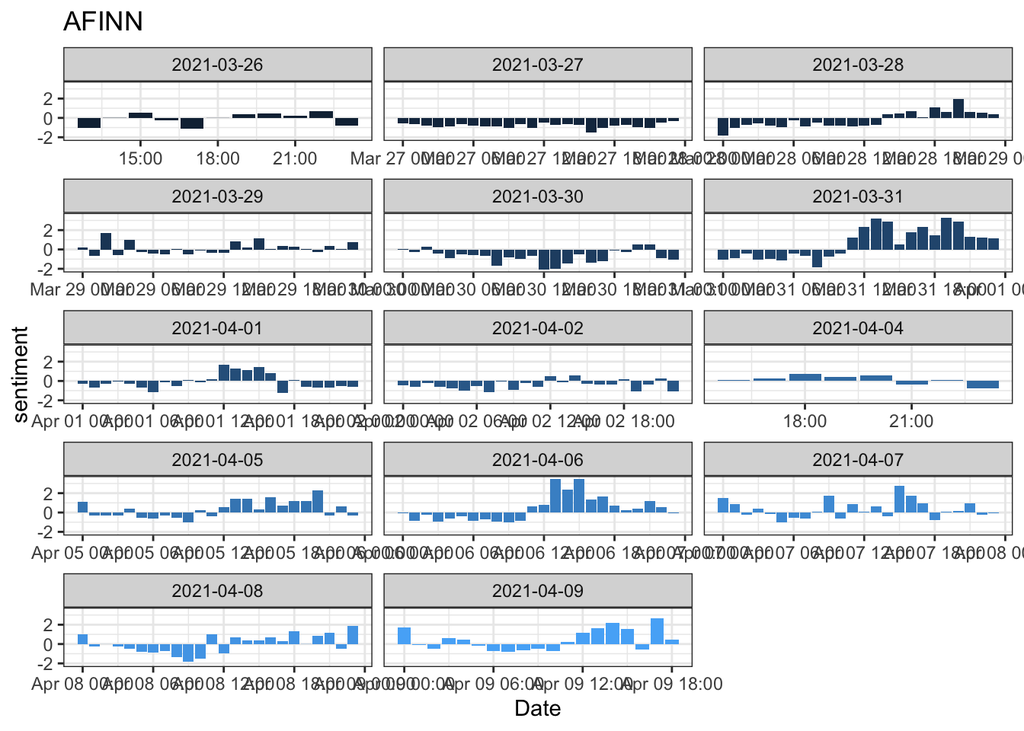

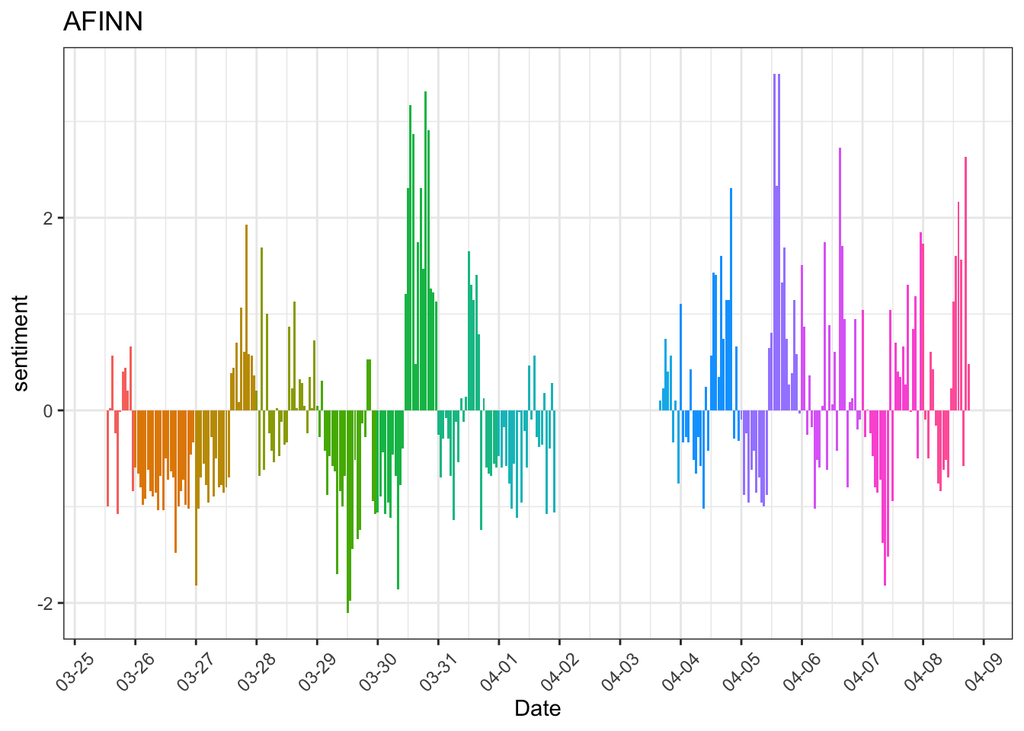

we compare the two sentiment plot together

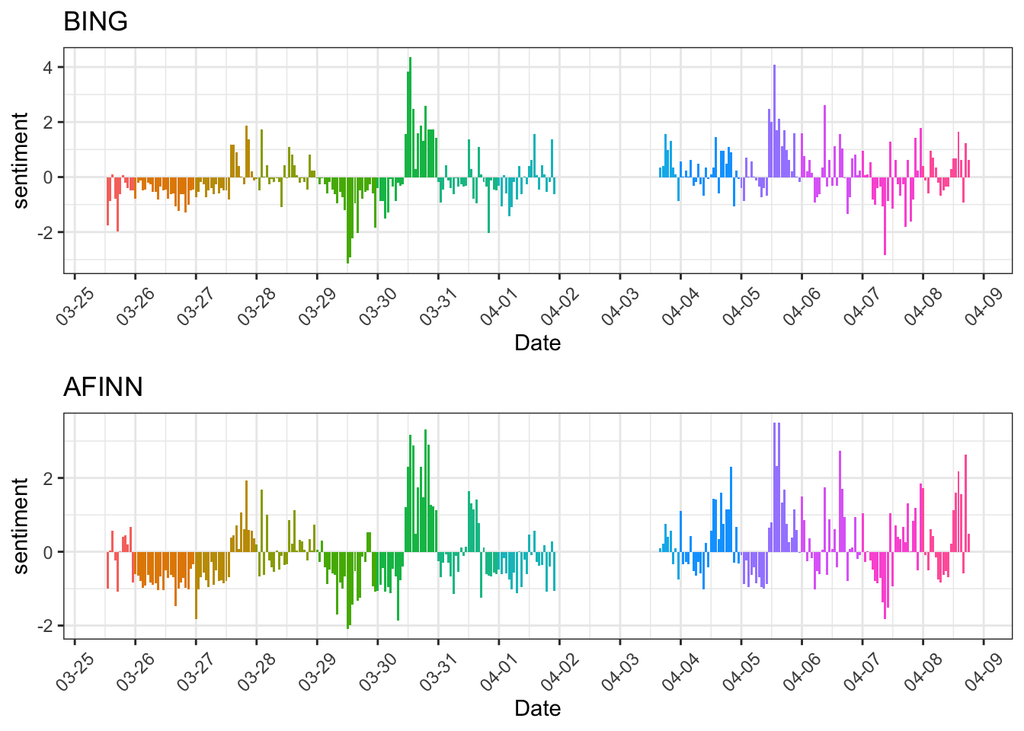

using t-test to check the whether there is a difference between bing lexicon and afinn lexicon, however the distriibution must be similar. ( this is meaningless, because we have already normalize the data, the distributio will be almost the same

```
## Response variable: numerical
## Explanatory variable: categorical (2 levels)
## n_afinn = 301, y_bar_afinn = 0, s_afinn = 1
## n_bing = 301, y_bar_bing = 0, s_bing = 1
## H0: mu_afinn =  mu_bing
## HA: mu_afinn != mu_bing
## t = 0, df = 300
## p_value = 1
```

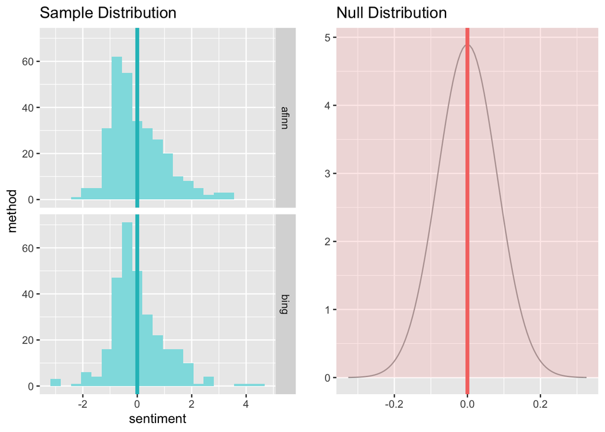

we should use the KS-test to check the distribution: as a result, reject the null h0, the distribution are different.

```
##
##  Two-sample Kolmogorov-Smirnov test
##
## data:  bing_afinn$bing and bing_afinn$afinn
## D = 0.11296, p-value = 0.04296
## alternative hypothesis: two-sided
```

Then, here is the method with nrc lexicon

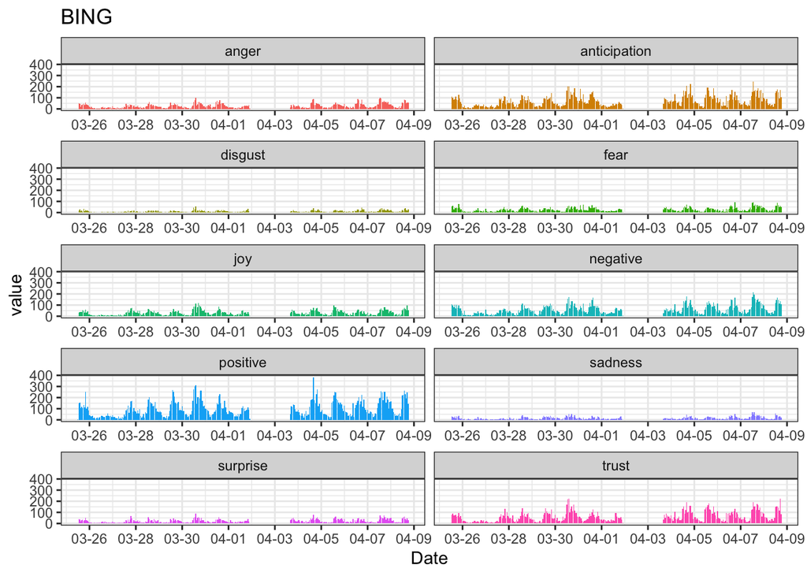

### top 10 bing_words Count

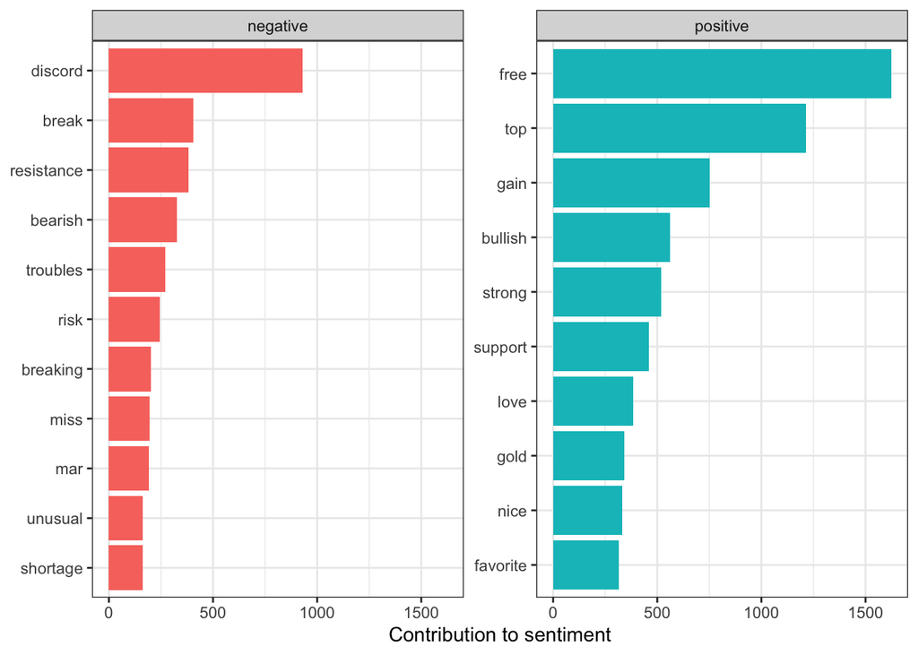

### top 10 nrc_words Count

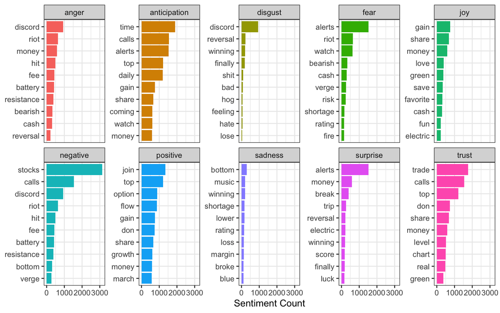

### Stock Information

```
## # A tibble: 6 x 2
##   time                price
##   <chr>               <dbl>
## 1 2021-03-26 03:00:00  121.
## 2 2021-03-26 04:00:00  121.
## 3 2021-03-26 05:00:00  121.
## 4 2021-03-26 06:00:00  120.
## 5 2021-03-26 07:00:00  120.
## 6 2021-03-26 08:00:00  120.
```

normalize the price data:

```
## # A tibble: 6 x 2
##   time                 price
##   <chr>                <dbl>
## 1 2021-03-26 03:00:00 -0.950
## 2 2021-03-26 04:00:00 -1.02
## 3 2021-03-26 05:00:00 -0.956
## 4 2021-03-26 06:00:00 -1.20
## 5 2021-03-26 07:00:00 -1.20
## 6 2021-03-26 08:00:00 -1.13
```

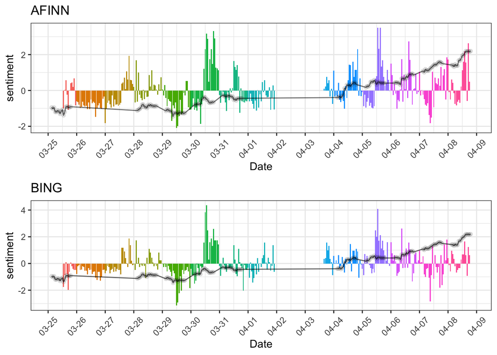

2. Build the model dataframe:

Here we need to deal with several questions: 1. Stock maket open at 9 am and close at 4 pm 2. At the open time, stock market record the XX:30, which is not consistent with sentimennt XX::00 3. At close time, stock market also record some stock price

Separate the dataframe into close data_frame and open data_frame

```
## # A tibble: 6 x 15
##   datetime             price date       time_stock anger anticipation disgust
##   <dttm>               <dbl> <date>     <chr>      <dbl>        <dbl>   <dbl>
## 1 2021-03-26 17:00:00 -0.948 2021-03-26 17:00         42          111       9
## 2 2021-03-26 18:00:00 -0.937 2021-03-26 18:00         46           83      33
## 3 2021-03-26 19:00:00 -0.908 2021-03-26 19:00         33           78      12
## 4 2021-03-29 03:00:00 -1.12  2021-03-29 03:00         12           50       1
## 5 2021-03-29 04:00:00 -1.07  2021-03-29 04:00         15           63       7
## 6 2021-03-29 05:00:00 -1.03  2021-03-29 05:00         18           43       4
## # … with 8 more variables: fear <dbl>, joy <dbl>, negative <dbl>,
## #   positive <dbl>, sadness <dbl>, surprise <dbl>, trust <dbl>, state <chr>
```

```
## # A tibble: 6 x 15
##   datetime             price date       time_stock anger anticipation disgust
##   <dttm>               <dbl> <date>     <chr>      <dbl>        <dbl>   <dbl>
## 1 2021-03-26 12:00:00 -1.07  2021-03-26 12:00          0            0       0
## 2 2021-03-26 13:00:00 -1.39  2021-03-26 13:00         50          110      20
## 3 2021-03-26 14:00:00 -1.20  2021-03-26 14:00         44           99      26
## 4 2021-03-26 15:00:00 -0.908 2021-03-26 15:00         20           82      13
## 5 2021-03-26 16:00:00 -0.903 2021-03-26 16:00         36           90      19
## 6 2021-03-29 09:00:00 -0.932 2021-03-29 09:00          6           16       0
## # … with 8 more variables: fear <dbl>, joy <dbl>, negative <dbl>,
## #   positive <dbl>, sadness <dbl>, surprise <dbl>, trust <dbl>, state <chr>
```

### AAPL NRC Regression Model result

1. this is the model for total recording

```
##
## Call:
## lm(formula = price ~ anger + anticipation + disgust + fear +
##     joy + negative + positive + sadness + surprise + trust, data = full_nrc)
##
## Residuals:
##     Min      1Q  Median      3Q     Max
## -1.7226 -0.7293 -0.0919  0.6076  1.9052
##
## Coefficients:
##              Estimate Std. Error t value Pr(>|t|)
## (Intercept)   0.04924    0.07181   0.686 0.493965
## anger         0.27278    0.25531   1.068 0.287053
## anticipation  0.30578    0.28906   1.058 0.291835
## disgust       0.34217    0.17085   2.003 0.047021 *
## fear          0.11403    0.20187   0.565 0.573014
## joy          -0.50471    0.19551  -2.581 0.010803 *
## negative     -0.47100    0.33781  -1.394 0.165311
## positive     -0.65553    0.26657  -2.459 0.015072 *
## sadness       0.09365    0.16564   0.565 0.572646
## surprise     -0.13354    0.21475  -0.622 0.535019
## trust         0.92332    0.26784   3.447 0.000736 ***
## ---
## Signif. codes:  0 '***' 0.001 '**' 0.01 '*' 0.05 '.' 0.1 ' ' 1
##
## Residual standard error: 0.9083 on 149 degrees of freedom
## Multiple R-squared:  0.1934, Adjusted R-squared:  0.1392
## F-statistic: 3.572 on 10 and 149 DF,  p-value: 0.0002882
```

2. this is the model for close recording

```
##
## Call:
## lm(formula = price ~ anger + anticipation + disgust + fear +
##     joy + negative + positive + sadness + surprise + trust, data = full_nrc[which(full_nrc$state ==
##     "close"), ])
##
## Residuals:
##      Min       1Q   Median       3Q      Max
## -1.38461 -0.64410 -0.06775  0.48235  1.83379
##
## Coefficients:
##              Estimate Std. Error t value Pr(>|t|)
## (Intercept)   0.18456    0.11865   1.555  0.12422
## anger         0.74444    0.49546   1.503  0.13733
## anticipation  0.49959    0.45611   1.095  0.27702
## disgust       0.44068    0.26163   1.684  0.09644 .
## fear         -0.10855    0.34296  -0.317  0.75254
## joy          -0.77887    0.31145  -2.501  0.01467 *
## negative     -1.01916    0.54894  -1.857  0.06746 .
## positive     -0.77631    0.52732  -1.472  0.14533
## sadness      -0.04488    0.33625  -0.133  0.89420
## surprise      0.26334    0.33987   0.775  0.44099
## trust         1.23353    0.46512   2.652  0.00983 **
## ---
## Signif. codes:  0 '***' 0.001 '**' 0.01 '*' 0.05 '.' 0.1 ' ' 1
##
## Residual standard error: 0.875 on 72 degrees of freedom
## Multiple R-squared:  0.2197, Adjusted R-squared:  0.1113
## F-statistic: 2.027 on 10 and 72 DF,  p-value: 0.04265
```

3. this is the model for open recording

```
##
## Call:
## lm(formula = price ~ anger + anticipation + disgust + fear +
##     joy + negative + positive + sadness + surprise + trust, data = full_nrc[which(full_nrc$state ==
##     "open"), ])
##
## Residuals:
##      Min       1Q   Median       3Q      Max
## -1.89578 -0.63536  0.04326  0.57980  1.84446
##
## Coefficients:
##              Estimate Std. Error t value Pr(>|t|)
## (Intercept)  -0.01233    0.11959  -0.103   0.9182
## anger        -0.11088    0.36313  -0.305   0.7611
## anticipation  0.46495    0.44272   1.050   0.2974
## disgust       0.48859    0.26761   1.826   0.0724 .
## fear          0.18123    0.27925   0.649   0.5186
## joy          -0.54007    0.31421  -1.719   0.0903 .
## negative     -0.02407    0.48489  -0.050   0.9606
## positive     -0.61641    0.34445  -1.790   0.0781 .
## sadness       0.18289    0.20056   0.912   0.3652
## surprise     -0.43670    0.30359  -1.438   0.1550
## trust         0.69157    0.36888   1.875   0.0652 .
## ---
## Signif. codes:  0 '***' 0.001 '**' 0.01 '*' 0.05 '.' 0.1 ' ' 1
##
## Residual standard error: 0.9485 on 66 degrees of freedom
## Multiple R-squared:  0.2698, Adjusted R-squared:  0.1592
## F-statistic: 2.439 on 10 and 66 DF,  p-value: 0.01531
```

the most relative variable is the trust sentiment, plotting its plot and stock price

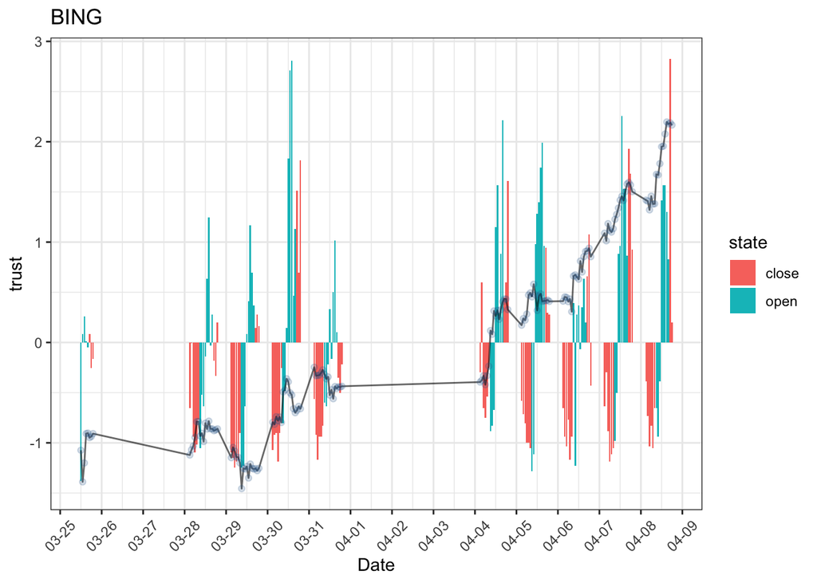

### NRC Decision Tree

maximum Tree

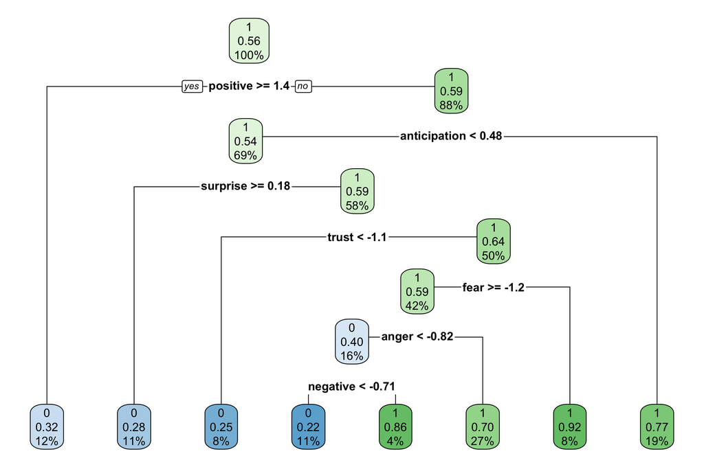

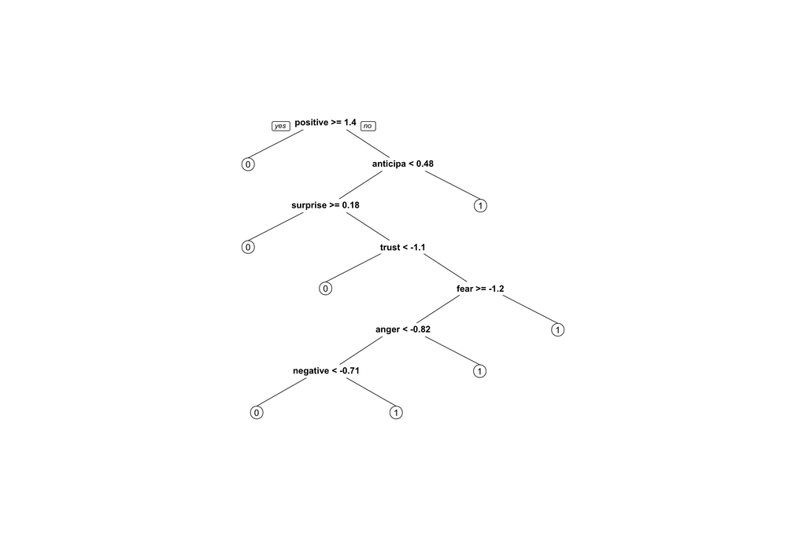

```
## Confusion Matrix and Statistics
##
##           Reference
## Prediction  0  1
##          0 49 18
##          1 22 71
##
##                Accuracy : 0.75
##                  95% CI : (0.6755, 0.815)
##     No Information Rate : 0.5562
##     P-Value [Acc > NIR] : 3.021e-07
##
##                   Kappa : 0.4907
##
##  Mcnemar's Test P-Value : 0.6353
##
##             Sensitivity : 0.6901
##             Specificity : 0.7978
##          Pos Pred Value : 0.7313
##          Neg Pred Value : 0.7634
##              Prevalence : 0.4437
##          Detection Rate : 0.3063
##    Detection Prevalence : 0.4188
##       Balanced Accuracy : 0.7439
##
##        'Positive' Class : 0
##
```